# Risk Factor Analysis

## Outcome Variable

**Outcome Variable:** y_rate_haz

## Predictor Variables

**Intervention Variable:** fage

**Adjustment Set:**

unadjusted

## Stratifying Variables

The analysis was stratified on these variable(s):

- diffcat
- studyid
- country

## Data Summary

| diffcat | studyid | country | fage | n_cell | n |
| --- | --- | --- | --- | --- | --- |
| 0-3 months | ki0047075b-MAL-ED | BANGLADESH | >=35 | 101 | 150 |
| 0-3 months | ki0047075b-MAL-ED | BANGLADESH | [25-30) | 14 | 150 |
| 0-3 months | ki0047075b-MAL-ED | BANGLADESH | [30-35) | 35 | 150 |
| 3-6 months | ki0047075b-MAL-ED | BANGLADESH | >=35 | 99 | 148 |
| 3-6 months | ki0047075b-MAL-ED | BANGLADESH | [25-30) | 14 | 148 |
| 3-6 months | ki0047075b-MAL-ED | BANGLADESH | [30-35) | 35 | 148 |
| 6-12 months | ki0047075b-MAL-ED | BANGLADESH | >=35 | 98 | 145 |
| 6-12 months | ki0047075b-MAL-ED | BANGLADESH | [25-30) | 14 | 145 |
| 6-12 months | ki0047075b-MAL-ED | BANGLADESH | [30-35) | 33 | 145 |
| 12-24 months | ki0047075b-MAL-ED | BANGLADESH | >=35 | 99 | 146 |
| 12-24 months | ki0047075b-MAL-ED | BANGLADESH | [25-30) | 14 | 146 |
| 12-24 months | ki0047075b-MAL-ED | BANGLADESH | [30-35) | 33 | 146 |
| 0-3 months | ki1119695-PROBIT | BELARUS | >=35 | 1242 | 12294 |
| 0-3 months | ki1119695-PROBIT | BELARUS | <25 | 4068 | 12294 |
| 0-3 months | ki1119695-PROBIT | BELARUS | [25-30) | 4633 | 12294 |
| 0-3 months | ki1119695-PROBIT | BELARUS | [30-35) | 2351 | 12294 |
| 3-6 months | ki1119695-PROBIT | BELARUS | >=35 | 1293 | 12816 |
| 3-6 months | ki1119695-PROBIT | BELARUS | <25 | 4314 | 12816 |
| 3-6 months | ki1119695-PROBIT | BELARUS | [25-30) | 4809 | 12816 |
| 3-6 months | ki1119695-PROBIT | BELARUS | [30-35) | 2400 | 12816 |
| 6-12 months | ki1119695-PROBIT | BELARUS | >=35 | 1275 | 12439 |
| 6-12 months | ki1119695-PROBIT | BELARUS | <25 | 4168 | 12439 |
| 6-12 months | ki1119695-PROBIT | BELARUS | [25-30) | 4659 | 12439 |
| 6-12 months | ki1119695-PROBIT | BELARUS | [30-35) | 2337 | 12439 |
| 12-24 months | ki1119695-PROBIT | BELARUS | >=35 | 268 | 2462 |
| 12-24 months | ki1119695-PROBIT | BELARUS | <25 | 764 | 2462 |
| 12-24 months | ki1119695-PROBIT | BELARUS | [25-30) | 959 | 2462 |
| 12-24 months | ki1119695-PROBIT | BELARUS | [30-35) | 471 | 2462 |
| 0-3 months | ki0047075b-MAL-ED | BRAZIL | >=35 | 35 | 68 |
| 0-3 months | ki0047075b-MAL-ED | BRAZIL | <25 | 3 | 68 |

[output cut: 158 more lines]

The following strata were considered:

- diffcat: 0-3 months, studyid: ki0047075b-MAL-ED, country: BANGLADESH
- diffcat: 0-3 months, studyid: ki0047075b-MAL-ED, country: BRAZIL
- diffcat: 0-3 months, studyid: ki0047075b-MAL-ED, country: INDIA
- diffcat: 0-3 months, studyid: ki0047075b-MAL-ED, country: NEPAL
- diffcat: 0-3 months, studyid: ki0047075b-MAL-ED, country: PERU
- diffcat: 0-3 months, studyid: ki0047075b-MAL-ED, country: SOUTH AFRICA
- diffcat: 0-3 months, studyid: ki0047075b-MAL-ED, country: TANZANIA, UNITED REPUBLIC OF
- diffcat: 0-3 months, studyid: ki1000304b-SAS-CompFeed, country: INDIA
- diffcat: 0-3 months, studyid: ki1119695-PROBIT, country: BELARUS
- diffcat: 0-3 months, studyid: ki1135781-COHORTS, country: GUATEMALA
- diffcat: 12-24 months, studyid: ki0047075b-MAL-ED, country: BANGLADESH
- diffcat: 12-24 months, studyid: ki0047075b-MAL-ED, country: BRAZIL
- diffcat: 12-24 months, studyid: ki0047075b-MAL-ED, country: INDIA
- diffcat: 12-24 months, studyid: ki0047075b-MAL-ED, country: NEPAL
- diffcat: 12-24 months, studyid: ki0047075b-MAL-ED, country: PERU
- diffcat: 12-24 months, studyid: ki0047075b-MAL-ED, country: SOUTH AFRICA
- diffcat: 12-24 months, studyid: ki0047075b-MAL-ED, country: TANZANIA, UNITED REPUBLIC OF
- diffcat: 12-24 months, studyid: ki1119695-PROBIT, country: BELARUS
- diffcat: 12-24 months, studyid: ki1135781-COHORTS, country: GUATEMALA
- diffcat: 12-24 months, studyid: ki1135781-COHORTS, country: PHILIPPINES
- diffcat: 12-24 months, studyid: ki1148112-iLiNS-DOSE, country: MALAWI
- diffcat: 12-24 months, studyid: ki1148112-iLiNS-DYAD-M, country: MALAWI
- diffcat: 12-24 months, studyid: ki1148112-LCNI-5, country: MALAWI
- diffcat: 3-6 months, studyid: ki0047075b-MAL-ED, country: BANGLADESH
- diffcat: 3-6 months, studyid: ki0047075b-MAL-ED, country: BRAZIL
- diffcat: 3-6 months, studyid: ki0047075b-MAL-ED, country: INDIA
- diffcat: 3-6 months, studyid: ki0047075b-MAL-ED, country: NEPAL
- diffcat: 3-6 months, studyid: ki0047075b-MAL-ED, country: PERU
- diffcat: 3-6 months, studyid: ki0047075b-MAL-ED, country: SOUTH AFRICA
- diffcat: 3-6 months, studyid: ki0047075b-MAL-ED, country: TANZANIA, UNITED REPUBLIC OF
- diffcat: 3-6 months, studyid: ki1000304b-SAS-CompFeed, country: INDIA
- diffcat: 3-6 months, studyid: ki1119695-PROBIT, country: BELARUS
- diffcat: 3-6 months, studyid: ki1135781-COHORTS, country: GUATEMALA
- diffcat: 3-6 months, studyid: ki1148112-iLiNS-DYAD-M, country: MALAWI
- diffcat: 6-12 months, studyid: ki0047075b-MAL-ED, country: BANGLADESH
- diffcat: 6-12 months, studyid: ki0047075b-MAL-ED, country: BRAZIL
- diffcat: 6-12 months, studyid: ki0047075b-MAL-ED, country: INDIA
- diffcat: 6-12 months, studyid: ki0047075b-MAL-ED, country: NEPAL
- diffcat: 6-12 months, studyid: ki0047075b-MAL-ED, country: PERU
- diffcat: 6-12 months, studyid: ki0047075b-MAL-ED, country: SOUTH AFRICA
- diffcat: 6-12 months, studyid: ki0047075b-MAL-ED, country: TANZANIA, UNITED REPUBLIC OF
- diffcat: 6-12 months, studyid: ki1000304b-SAS-CompFeed, country: INDIA
- diffcat: 6-12 months, studyid: ki1000304b-SAS-FoodSuppl, country: INDIA
- diffcat: 6-12 months, studyid: ki1119695-PROBIT, country: BELARUS
- diffcat: 6-12 months, studyid: ki1135781-COHORTS, country: GUATEMALA
- diffcat: 6-12 months, studyid: ki1135781-COHORTS, country: PHILIPPINES
- diffcat: 6-12 months, studyid: ki1148112-iLiNS-DOSE, country: MALAWI
- diffcat: 6-12 months, studyid: ki1148112-iLiNS-DYAD-M, country: MALAWI
- diffcat: 6-12 months, studyid: ki1148112-LCNI-5, country: MALAWI

### Dropped Strata

Some strata were dropped due to rare outcomes:

- diffcat: 0-3 months, studyid: ki0047075b-MAL-ED, country: BRAZIL
- diffcat: 3-6 months, studyid: ki0047075b-MAL-ED, country: BRAZIL
- diffcat: 6-12 months, studyid: ki0047075b-MAL-ED, country: BRAZIL
- diffcat: 12-24 months, studyid: ki0047075b-MAL-ED, country: BRAZIL
- diffcat: 0-3 months, studyid: ki0047075b-MAL-ED, country: INDIA
- diffcat: 3-6 months, studyid: ki0047075b-MAL-ED, country: INDIA
- diffcat: 6-12 months, studyid: ki0047075b-MAL-ED, country: INDIA
- diffcat: 12-24 months, studyid: ki0047075b-MAL-ED, country: INDIA
- diffcat: 3-6 months, studyid: ki1148112-iLiNS-DYAD-M, country: MALAWI
- diffcat: 0-3 months, studyid: ki0047075b-MAL-ED, country: PERU
- diffcat: 6-12 months, studyid: ki0047075b-MAL-ED, country: PERU
- diffcat: 12-24 months, studyid: ki0047075b-MAL-ED, country: PERU
- diffcat: 0-3 months, studyid: ki0047075b-MAL-ED, country: SOUTH AFRICA
- diffcat: 3-6 months, studyid: ki0047075b-MAL-ED, country: SOUTH AFRICA
- diffcat: 6-12 months, studyid: ki0047075b-MAL-ED, country: SOUTH AFRICA
- diffcat: 12-24 months, studyid: ki0047075b-MAL-ED, country: SOUTH AFRICA
- diffcat: 0-3 months, studyid: ki0047075b-MAL-ED, country: TANZANIA, UNITED REPUBLIC OF
- diffcat: 3-6 months, studyid: ki0047075b-MAL-ED, country: TANZANIA, UNITED REPUBLIC OF
- diffcat: 6-12 months, studyid: ki0047075b-MAL-ED, country: TANZANIA, UNITED REPUBLIC OF
- diffcat: 12-24 months, studyid: ki0047075b-MAL-ED, country: TANZANIA, UNITED REPUBLIC OF

## Methods Detail

We’re interested in the causal parameters $E[Y_a]$ for all values of $a \in \mathcal{A}$. These parameters represent the mean outcome if, possibly contrary to fact, we intervened to set all units to have $A=a$. Under the randomization and positivity assumptions, these are identified by the statistical parameters $\psi_a=E_W[E_{Y|A,W}(Y|A=a,W)]$. In addition, we’re interested in the mean of $Y$, $E[Y]$ under no intervention (the observed mean). We will estimate these parameters by using SuperLearner to fit the relevant likelihood factors – $E_{Y|A,W}(Y|A=a,W)$ and $p(A=a|W)$, and then updating our likelihood fit using a joint TMLE.

For unadjusted analyses ($W=\{\}$), initial likelihoods were estimated using Lrnr_glm to estimate the simple $E(Y|A)$ and Lrnr_mean to estimate $p(A)$. For adjusted analyses, a small library containing Lrnr_glmnet, Lrnr_xgboost, and Lrnr_mean was used.

Having estimated these parameters, we will then use the delta method to estimate relative risks and attributable risks relative to a prespecified baseline level of $A$.

# Results Detail

## Results Plots

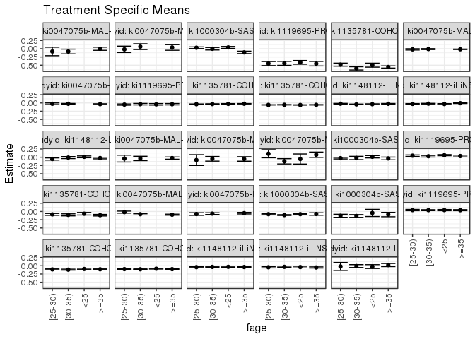

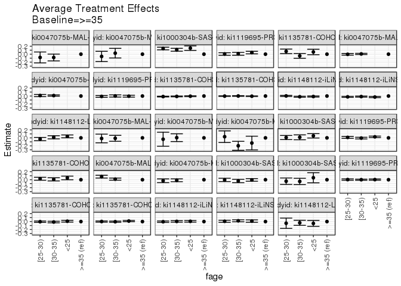

## Results Table

### Parameter: TSM

| diffcat | studyid | country | intervention_level | baseline_level | estimate | ci_lower | ci_upper |
| --- | --- | --- | --- | --- | --- | --- | --- |
| 0-3 months | ki0047075b-MAL-ED | BANGLADESH | >=35 | NA | -0.0016565 | -0.0487223 | 0.0454093 |
| 0-3 months | ki0047075b-MAL-ED | BANGLADESH | [25-30) | NA | -0.0840215 | -0.2122099 | 0.0441670 |
| 0-3 months | ki0047075b-MAL-ED | BANGLADESH | [30-35) | NA | -0.0850177 | -0.1568209 | -0.0132145 |
| 0-3 months | ki0047075b-MAL-ED | NEPAL | >=35 | NA | 0.0377725 | -0.0469721 | 0.1225171 |
| 0-3 months | ki0047075b-MAL-ED | NEPAL | [25-30) | NA | -0.0191325 | -0.1161309 | 0.0778658 |
| 0-3 months | ki0047075b-MAL-ED | NEPAL | [30-35) | NA | 0.0632070 | -0.0236921 | 0.1501060 |
| 0-3 months | ki1000304b-SAS-CompFeed | INDIA | >=35 | NA | -0.1121832 | -0.1497581 | -0.0746083 |
| 0-3 months | ki1000304b-SAS-CompFeed | INDIA | <25 | NA | 0.0392608 | 0.0102119 | 0.0683098 |
| 0-3 months | ki1000304b-SAS-CompFeed | INDIA | [25-30) | NA | 0.0300924 | 0.0043663 | 0.0558185 |
| 0-3 months | ki1000304b-SAS-CompFeed | INDIA | [30-35) | NA | -0.0010866 | -0.0391889 | 0.0370156 |
| 0-3 months | ki1119695-PROBIT | BELARUS | >=35 | NA | -0.4543652 | -0.5233650 | -0.3853654 |
| 0-3 months | ki1119695-PROBIT | BELARUS | <25 | NA | -0.4145183 | -0.4713455 | -0.3576911 |
| 0-3 months | ki1119695-PROBIT | BELARUS | [25-30) | NA | -0.4495863 | -0.5112353 | -0.3879373 |
| 0-3 months | ki1119695-PROBIT | BELARUS | [30-35) | NA | -0.4441852 | -0.5047925 | -0.3835780 |
| 0-3 months | ki1135781-COHORTS | GUATEMALA | >=35 | NA | -0.5544558 | -0.5880284 | -0.5208833 |
| 0-3 months | ki1135781-COHORTS | GUATEMALA | <25 | NA | -0.4989792 | -0.5595827 | -0.4383756 |
| 0-3 months | ki1135781-COHORTS | GUATEMALA | [25-30) | NA | -0.4834251 | -0.5294675 | -0.4373828 |
| 0-3 months | ki1135781-COHORTS | GUATEMALA | [30-35) | NA | -0.5965919 | -0.6458329 | -0.5473509 |
| 3-6 months | ki0047075b-MAL-ED | BANGLADESH | >=35 | NA | -0.0271101 | -0.0612083 | 0.0069880 |
| 3-6 months | ki0047075b-MAL-ED | BANGLADESH | [25-30) | NA | -0.0420665 | -0.1461106 | 0.0619775 |
| 3-6 months | ki0047075b-MAL-ED | BANGLADESH | [30-35) | NA | -0.0380749 | -0.1046520 | 0.0285022 |
| 3-6 months | ki0047075b-MAL-ED | NEPAL | >=35 | NA | -0.0530226 | -0.1208985 | 0.0148533 |
| 3-6 months | ki0047075b-MAL-ED | NEPAL | [25-30) | NA | -0.0868105 | -0.2496965 | 0.0760756 |
| 3-6 months | ki0047075b-MAL-ED | NEPAL | [30-35) | NA | -0.0482421 | -0.1187317 | 0.0222476 |
| 3-6 months | ki0047075b-MAL-ED | PERU | >=35 | NA | 0.0753255 | -0.0043930 | 0.1550441 |
| 3-6 months | ki0047075b-MAL-ED | PERU | <25 | NA | -0.0543771 | -0.2072018 | 0.0984477 |
| 3-6 months | ki0047075b-MAL-ED | PERU | [25-30) | NA | 0.1052323 | -0.0168652 | 0.2273298 |
| 3-6 months | ki0047075b-MAL-ED | PERU | [30-35) | NA | -0.1240811 | -0.2044659 | -0.0436964 |
| 3-6 months | ki1000304b-SAS-CompFeed | INDIA | >=35 | NA | -0.0373134 | -0.0788028 | 0.0041760 |
| 3-6 months | ki1000304b-SAS-CompFeed | INDIA | <25 | NA | 0.0138888 | -0.0214987 | 0.0492762 |

[output cut: 78 more lines]

### Parameter: E(Y)

| diffcat | studyid | country | intervention_level | baseline_level | estimate | ci_lower | ci_upper |
| --- | --- | --- | --- | --- | --- | --- | --- |
| 0-3 months | ki0047075b-MAL-ED | BANGLADESH | NA | NA | -0.0287949 | -0.0671002 | 0.0095105 |
| 0-3 months | ki0047075b-MAL-ED | NEPAL | NA | NA | 0.0411390 | -0.0145546 | 0.0968327 |
| 0-3 months | ki1000304b-SAS-CompFeed | INDIA | NA | NA | 0.0124966 | -0.0032603 | 0.0282535 |
| 0-3 months | ki1119695-PROBIT | BELARUS | NA | NA | -0.4374325 | -0.4965010 | -0.3783639 |
| 0-3 months | ki1135781-COHORTS | GUATEMALA | NA | NA | -0.5405498 | -0.5629687 | -0.5181310 |
| 3-6 months | ki0047075b-MAL-ED | BANGLADESH | NA | NA | -0.0311179 | -0.0605438 | -0.0016921 |
| 3-6 months | ki0047075b-MAL-ED | NEPAL | NA | NA | -0.0554236 | -0.1029996 | -0.0078477 |
| 3-6 months | ki0047075b-MAL-ED | PERU | NA | NA | 0.0351978 | -0.0209986 | 0.0913942 |
| 3-6 months | ki1000304b-SAS-CompFeed | INDIA | NA | NA | -0.0168853 | -0.0357401 | 0.0019694 |
| 3-6 months | ki1119695-PROBIT | BELARUS | NA | NA | 0.0473064 | 0.0279787 | 0.0666342 |
| 3-6 months | ki1135781-COHORTS | GUATEMALA | NA | NA | -0.0986159 | -0.1135079 | -0.0837240 |
| 6-12 months | ki0047075b-MAL-ED | BANGLADESH | NA | NA | -0.0860818 | -0.0985610 | -0.0736027 |
| 6-12 months | ki0047075b-MAL-ED | NEPAL | NA | NA | -0.0595839 | -0.0760822 | -0.0430856 |
| 6-12 months | ki1000304b-SAS-CompFeed | INDIA | NA | NA | -0.0858013 | -0.0900320 | -0.0815706 |
| 6-12 months | ki1000304b-SAS-FoodSuppl | INDIA | NA | NA | -0.1080113 | -0.1390238 | -0.0769988 |
| 6-12 months | ki1119695-PROBIT | BELARUS | NA | NA | 0.0416292 | 0.0251876 | 0.0580707 |
| 6-12 months | ki1135781-COHORTS | GUATEMALA | NA | NA | -0.1091839 | -0.1163423 | -0.1020255 |
| 6-12 months | ki1135781-COHORTS | PHILIPPINES | NA | NA | -0.0999580 | -0.1051268 | -0.0947892 |
| 6-12 months | ki1148112-iLiNS-DOSE | MALAWI | NA | NA | -0.0380903 | -0.0451716 | -0.0310090 |
| 6-12 months | ki1148112-iLiNS-DYAD-M | MALAWI | NA | NA | -0.0434141 | -0.0533419 | -0.0334863 |
| 6-12 months | ki1148112-LCNI-5 | MALAWI | NA | NA | -0.0054695 | -0.0426418 | 0.0317029 |
| 12-24 months | ki0047075b-MAL-ED | BANGLADESH | NA | NA | -0.0162473 | -0.0222513 | -0.0102433 |
| 12-24 months | ki0047075b-MAL-ED | NEPAL | NA | NA | -0.0298967 | -0.0377257 | -0.0220676 |
| 12-24 months | ki1119695-PROBIT | BELARUS | NA | NA | -0.0429788 | -0.0603736 | -0.0255841 |
| 12-24 months | ki1135781-COHORTS | GUATEMALA | NA | NA | -0.0294369 | -0.0331367 | -0.0257372 |
| 12-24 months | ki1135781-COHORTS | PHILIPPINES | NA | NA | -0.0579786 | -0.0605237 | -0.0554336 |
| 12-24 months | ki1148112-iLiNS-DOSE | MALAWI | NA | NA | -0.0304152 | -0.0353462 | -0.0254842 |
| 12-24 months | ki1148112-iLiNS-DYAD-M | MALAWI | NA | NA | -0.0209165 | -0.0260918 | -0.0157413 |
| 12-24 months | ki1148112-LCNI-5 | MALAWI | NA | NA | -0.0199381 | -0.0356954 | -0.0041807 |

### Parameter: ATE

| diffcat | studyid | country | intervention_level | baseline_level | estimate | ci_lower | ci_upper |
| --- | --- | --- | --- | --- | --- | --- | --- |
| 0-3 months | ki0047075b-MAL-ED | BANGLADESH | >=35 | >=35 | 0.0000000 | 0.0000000 | 0.0000000 |
| 0-3 months | ki0047075b-MAL-ED | BANGLADESH | [25-30) | >=35 | -0.0823650 | -0.2189207 | 0.0541908 |
| 0-3 months | ki0047075b-MAL-ED | BANGLADESH | [30-35) | >=35 | -0.0833612 | -0.1692151 | 0.0024927 |
| 0-3 months | ki0047075b-MAL-ED | NEPAL | >=35 | >=35 | 0.0000000 | 0.0000000 | 0.0000000 |
| 0-3 months | ki0047075b-MAL-ED | NEPAL | [25-30) | >=35 | -0.0569050 | -0.1857085 | 0.0718984 |
| 0-3 months | ki0047075b-MAL-ED | NEPAL | [30-35) | >=35 | 0.0254345 | -0.0959455 | 0.1468144 |
| 0-3 months | ki1000304b-SAS-CompFeed | INDIA | >=35 | >=35 | 0.0000000 | 0.0000000 | 0.0000000 |
| 0-3 months | ki1000304b-SAS-CompFeed | INDIA | <25 | >=35 | 0.1514440 | 0.0948740 | 0.2080140 |
| 0-3 months | ki1000304b-SAS-CompFeed | INDIA | [25-30) | >=35 | 0.1422756 | 0.1090913 | 0.1754600 |
| 0-3 months | ki1000304b-SAS-CompFeed | INDIA | [30-35) | >=35 | 0.1110966 | 0.0745133 | 0.1476799 |
| 0-3 months | ki1119695-PROBIT | BELARUS | >=35 | >=35 | 0.0000000 | 0.0000000 | 0.0000000 |
| 0-3 months | ki1119695-PROBIT | BELARUS | <25 | >=35 | 0.0398469 | 0.0078882 | 0.0718055 |
| 0-3 months | ki1119695-PROBIT | BELARUS | [25-30) | >=35 | 0.0047789 | -0.0271633 | 0.0367211 |
| 0-3 months | ki1119695-PROBIT | BELARUS | [30-35) | >=35 | 0.0101800 | -0.0260343 | 0.0463943 |
| 0-3 months | ki1135781-COHORTS | GUATEMALA | >=35 | >=35 | 0.0000000 | 0.0000000 | 0.0000000 |
| 0-3 months | ki1135781-COHORTS | GUATEMALA | <25 | >=35 | 0.0554766 | -0.0138047 | 0.1247580 |
| 0-3 months | ki1135781-COHORTS | GUATEMALA | [25-30) | >=35 | 0.0710307 | 0.0140481 | 0.1280132 |
| 0-3 months | ki1135781-COHORTS | GUATEMALA | [30-35) | >=35 | -0.0421361 | -0.1017330 | 0.0174608 |
| 3-6 months | ki0047075b-MAL-ED | BANGLADESH | >=35 | >=35 | 0.0000000 | 0.0000000 | 0.0000000 |
| 3-6 months | ki0047075b-MAL-ED | BANGLADESH | [25-30) | >=35 | -0.0149564 | -0.1244454 | 0.0945326 |
| 3-6 months | ki0047075b-MAL-ED | BANGLADESH | [30-35) | >=35 | -0.0109648 | -0.0857658 | 0.0638363 |
| 3-6 months | ki0047075b-MAL-ED | NEPAL | >=35 | >=35 | 0.0000000 | 0.0000000 | 0.0000000 |
| 3-6 months | ki0047075b-MAL-ED | NEPAL | [25-30) | >=35 | -0.0337878 | -0.2102503 | 0.1426746 |
| 3-6 months | ki0047075b-MAL-ED | NEPAL | [30-35) | >=35 | 0.0047806 | -0.0930761 | 0.1026372 |
| 3-6 months | ki0047075b-MAL-ED | PERU | >=35 | >=35 | 0.0000000 | 0.0000000 | 0.0000000 |
| 3-6 months | ki0047075b-MAL-ED | PERU | <25 | >=35 | -0.1297026 | -0.3020699 | 0.0426646 |
| 3-6 months | ki0047075b-MAL-ED | PERU | [25-30) | >=35 | 0.0299068 | -0.1159111 | 0.1757246 |
| 3-6 months | ki0047075b-MAL-ED | PERU | [30-35) | >=35 | -0.1994067 | -0.3126178 | -0.0861956 |
| 3-6 months | ki1000304b-SAS-CompFeed | INDIA | >=35 | >=35 | 0.0000000 | 0.0000000 | 0.0000000 |
| 3-6 months | ki1000304b-SAS-CompFeed | INDIA | <25 | >=35 | 0.0512022 | -0.0038229 | 0.1062273 |

[output cut: 78 more lines]